# 13.Example 2

Modified

Mo 2026-09-21 21:40

## Given:

The cover glass on a flat-plate solar collector has a low iron content, and its spectral transmissivity may be approximated by the following distribution.

Figure 1: Spectral Transmissivity

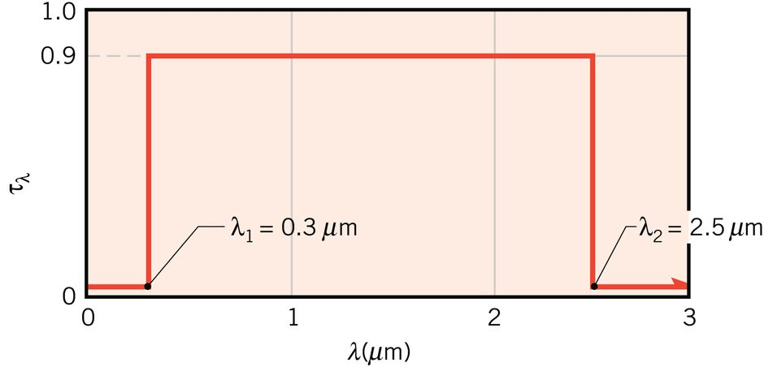

## Required:

What is the total transmissivity of the cover glass to solar radiation?

## Solution:

Start first by defining all of the given values.

$$\tau_1 = 0.9$$
$$\lambda_1 = 0.3\ \mathrm{μm}$$
$$\lambda_2 = 2.5\ \mathrm{μm}$$

The total transmissivity of the cover is given by

$$\tau = \frac{\int_0^\infty \tau_\lambda G_\lambda d \lambda}{\int_0^\infty G_\lambda d\lambda}$$

where the irradiation $G_\lambda$ is due to solar emission. Having assumed that the sun emits as a blackbody at $T = 5800\ \mathrm{K}$, it follows that

$$G_\lambda \left( \lambda \right) \propto E_{\lambda, b} \left(T = 5800 K \right)$$

The total transmissivity may then be written as

$$\tau = \frac{\int_0^\infty \tau_\lambda E_{\lambda, b} \left( 5800 K \right) d \lambda}{\int_0^\infty E_{\lambda, b} \left( 5800 K \right) d\lambda}$$

The expression above may be further simplified by first recognizing that the denominator is the emissive power of a blackbody at $5800 K$.

$$\tau = \frac{\int_0^\infty \tau_\lambda E_{\lambda, b} \left( 5800 K \right) d \lambda}{E_b \left( 5800 K \right)}$$

The second step to simplify the expression above is to split the numerator’s integral into different regions.

$$\tau = \frac{\int_0^{\lambda_1} \tau_0 E_{\lambda, b} \left( 5800 K \right) d \lambda}{E_b \left( 5800 K \right)} + \frac{\int_{\lambda_1}^{\lambda_2} \tau_1 E_{\lambda, b} \left( 5800 K \right) d \lambda}{E_b \left( 5800 K \right)} + \frac{\int_{\lambda_2}^\infty \tau_0 E_{\lambda, b} \left( 5800 K \right) d \lambda}{E_b \left( 5800 K \right)}$$

Using the plot given in the problem statement, it may be realized that the first and last region go to zero. The simplified expression then becomes

$$\tau = \frac{\int_{\lambda_1}^{\lambda_2} \tau_1 E_{\lambda, b} \left( 5800 K \right) d \lambda}{E_b \left( 5800 K \right)}$$

Once the transmissivity has been taken out of the integral, it may be recognized that the remaining fraction is the $F$ from Table 9 of the Quiz 5 Formula Sheet. This is written as

$$\tau = \tau_1 F_{\lambda_1 \rightarrow \lambda_2} = \tau_1 \left( F_{0 \rightarrow \lambda_2} - F_{0 \rightarrow \lambda_1} \right)$$

To use Table 9, the product of the wavelength and temperature is used.

$$(\lambda T)_1 = \lambda_1 T = 1740.0\ \mathrm{K} \cdot \mathrm{μm}$$

$$(\lambda T)_2 = \lambda_2 T = 14500.0\ \mathrm{K} \cdot \mathrm{μm}$$

Referring to Table 9, it may be seen that interpolation is needed.

The total transmissivity is then